# 2_map_matching_issues

Martine Besse

2023-06-08

```r
# Import posmo and add variables

#import and convert to sf object
posmo <- read_csv("./data/posmo_2023-06-08.csv") %>% st_as_sf(coords = c("lon_x", "lat_y"), crs=4326, remove = FALSE) |> st_transform(2056)
#add East and North columns
coords <- posmo |> st_coordinates()
posmo <- posmo |>
  mutate(E =  coords[,1], N = coords[,2])

#update timezone
posmo <- posmo %>%
  mutate(
    datetime = datetime %>% with_tz(tzone = "Europe/Zurich")
  )


#compute new values
#timelag
posmo <- mutate(posmo, timelag = as.numeric(difftime(lead(datetime), datetime)))

#steplength
posmo <- posmo %>% mutate(steplength_m = sqrt((E-lead(E))^2 + (N-lead(N))^2))

#speed
posmo <- posmo %>% mutate(speed_ms = steplength_m/timelag)
```

# Map matching issues cases

In this markdown, I will present two cases of map matching to show that the processed data downloaded from posmo was indeed map-matched.

## First example

Trip from Villars-le-Terroir to Prilly:  
- Bus from Villars-le-Terroir to Echallens  
- Train (LEB) from Echallens to Union-Prilly.

Here is a screenshot of what is visible on https://posmo.datamap.io/streaming:

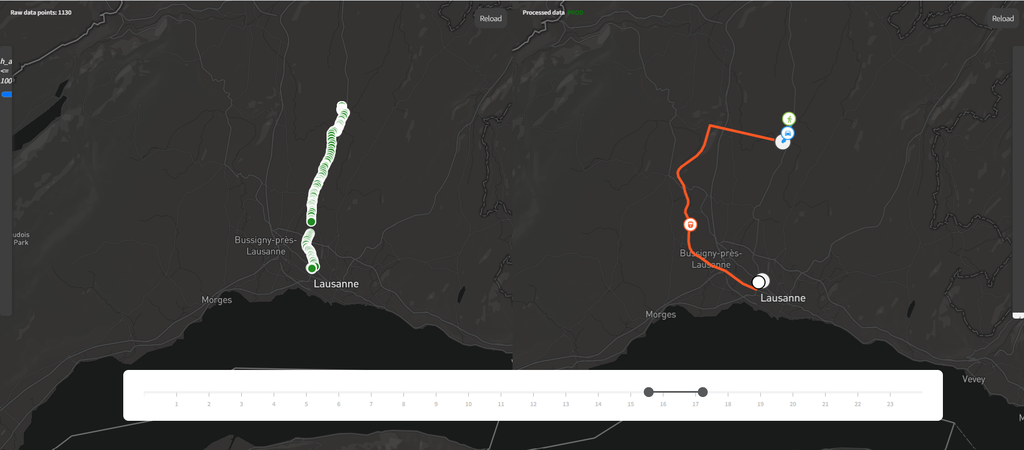

The left side present the raw data. The right the processed data.  
As we can see, the raw trajectory (real trajectory) do not coincide with the processed one:  
The bus trajectory is fine, but the train has been map matched to another railway near Eclépens.

The map below presents the data downloaded on posmo.datamap.io.  
As we can see, it is the match-mapped one, and no the raw one.

```r
posmo_issue1 <- posmo |>
    filter(datetime > as.POSIXct("2023-03-31 16:10:00", tz = "Europe/Zurich") & datetime < as.POSIXct("2023-03-31 16:50:00", tz = "Europe/Zurich"))  %>% mutate(tmode_manual = "train")
posmo_issue1
```

```
## Simple feature collection with 605 features and 13 fields
## Geometry type: POINT
## Dimension:     XY
## Bounding box:  xmin: 2529400 ymin: 1153336 xmax: 2539084 ymax: 1167813
## Projected CRS: CH1903+ / LV95
## # A tibble: 605 × 14
##    user_id     datetime            weekday place_name transport_mode lon_x lat_y
##  * <chr>       <dttm>              <chr>   <chr>      <chr>          <dbl> <dbl>
##  1 87e84c1a-0… 2023-03-31 16:11:07 Fri     <NA>       Walk            6.64  46.7
##  2 87e84c1a-0… 2023-03-31 16:11:07 Fri     <NA>       Walk            6.64  46.7
##  3 87e84c1a-0… 2023-03-31 16:11:59 Fri     <NA>       Walk            6.64  46.7
##  4 87e84c1a-0… 2023-03-31 16:12:09 Fri     <NA>       Walk            6.64  46.7
##  5 87e84c1a-0… 2023-03-31 16:12:18 Fri     <NA>       Walk            6.64  46.7
##  6 87e84c1a-0… 2023-03-31 16:12:27 Fri     <NA>       Walk            6.64  46.7
##  7 87e84c1a-0… 2023-03-31 16:12:36 Fri     <NA>       Walk            6.64  46.7
##  8 87e84c1a-0… 2023-03-31 16:12:45 Fri     <NA>       Walk            6.64  46.7
##  9 87e84c1a-0… 2023-03-31 16:12:54 Fri     <NA>       Walk            6.64  46.7
## 10 87e84c1a-0… 2023-03-31 16:13:03 Fri     <NA>       Walk            6.64  46.7
## # ℹ 595 more rows
## # ℹ 7 more variables: geometry <POINT [m]>, E <dbl>, N <dbl>, timelag <dbl>,
## #   steplength_m <dbl>, speed_ms <dbl>, tmode_manual <chr>
```

See map:

```r
posmo_issue1_wgs <- posmo_issue1 %>% st_transform(crs = 4326)

m <- leaflet() %>%
  addTiles() %>%  # Add default OpenStreetMap map tiles
  addCircleMarkers(data = posmo_issue1_wgs,
                   #opacity = 0.3,
                   radius = 0.2,
                   popup = posmo_issue1_wgs$datetime,
                   color = 'blue') %>%
  addLegend(position = 'topright',
            colors = c('blue'),
            labels = c('points'),
            title = 'Downloaded points from posmo')

# Plot the leaflet object m
m
```

[interactive chart not shown]

## Second example

Trip from Yverdon-les-Bains to Montricher.  
I took the car from Yverdon-les-Bains to Montricher and nothing else.

Here is a screenshot of what is visible on https://posmo.datamap.io/streaming:

[figure not shown]

The map below presents the data downloaded on posmo.datamap.io.

```r
posmo_issue2 <- posmo |>
    filter(datetime > as.POSIXct("2023-06-02 18:00:00", tz = "Europe/Zurich") & datetime < as.POSIXct("2023-06-02 19:00:00", tz = "Europe/Zurich"))
posmo_issue2
```

```
## Simple feature collection with 701 features and 12 fields
## Geometry type: POINT
## Dimension:     XY
## Bounding box:  xmin: 2514666 ymin: 1161080 xmax: 2539937 ymax: 1181472
## Projected CRS: CH1903+ / LV95
## # A tibble: 701 × 13
##    user_id     datetime            weekday place_name transport_mode lon_x lat_y
##  * <chr>       <dttm>              <chr>   <chr>      <chr>          <dbl> <dbl>
##  1 87e84c1a-0… 2023-06-02 18:00:02 Fri     <NA>       Car             6.64  46.8
##  2 87e84c1a-0… 2023-06-02 18:00:11 Fri     <NA>       Car             6.64  46.8
##  3 87e84c1a-0… 2023-06-02 18:00:20 Fri     <NA>       Car             6.64  46.8
##  4 87e84c1a-0… 2023-06-02 18:00:29 Fri     <NA>       Car             6.64  46.8
##  5 87e84c1a-0… 2023-06-02 18:00:38 Fri     <NA>       Car             6.64  46.8
##  6 87e84c1a-0… 2023-06-02 18:00:47 Fri     <NA>       Car             6.64  46.8
##  7 87e84c1a-0… 2023-06-02 18:00:56 Fri     <NA>       Car             6.64  46.8
##  8 87e84c1a-0… 2023-06-02 18:01:05 Fri     <NA>       Car             6.64  46.8
##  9 87e84c1a-0… 2023-06-02 18:01:14 Fri     <NA>       Car             6.64  46.8
## 10 87e84c1a-0… 2023-06-02 18:01:23 Fri     <NA>       Car             6.64  46.8
## # ℹ 691 more rows
## # ℹ 6 more variables: geometry <POINT [m]>, E <dbl>, N <dbl>, timelag <dbl>,
## #   steplength_m <dbl>, speed_ms <dbl>
```

```r
posmo_issue2_wgs <- posmo_issue2 %>% st_transform(crs = 4326)

m <- leaflet() %>%
  addTiles() %>%  # Add default OpenStreetMap map tiles
  addCircleMarkers(data = posmo_issue2_wgs,
                   #opacity = 0.3,
                   radius = 0.2,
                   popup = posmo_issue2_wgs$datetime,
                   color = 'blue') %>%
  addLegend(position = 'topright',
            colors = c('blue'),
            labels = c('points'),
            title = 'Downloaded points from posmo')

# Plot the leaflet object m
m
```

[interactive chart not shown]

# Questions

- If these are not clear proofs of map-matching, what are they?
- Is it possible to get the raw data and not the processed data?
- If not, what is the reason?

Getting the raw data would be a key point in our project.